# Probability Distributions

# Installing the Packages

```r
install.packages("tidyverse")
```

```
Error in install.packages : Updating loaded packages
```

```r
install.packages("readr")
```

```
Error in install.packages : Updating loaded packages
```

```r
install.packages("moments")
```

```r
install.packages("moments")
```

# Load the Packages

```r
library(tidyverse)
library(readr)
library(moments)
```

# Getting the data set

```r
LaLiga <- read.csv("Liga.csv")

LaLiga
```

| Season | Position | Crest.names | Team | City | Points | Matches | Won | Draw | Lost | Scored | Conceded | GoalDifference |
| --- | --- | --- | --- | --- | --- | --- | --- | --- | --- | --- | --- | --- |
| 1987-88 | 1 | Real Madrid | Real Madrid | Madrid | 62 | 38 | 28 | 6 | 4 | 95 | 26 | 69 |
| 1987-88 | 2 | Real Sociedad | Real Sociedad | San Sebastian | 51 | 38 | 22 | 7 | 9 | 61 | 33 | 28 |
| 1987-88 | 3 | Atlético de Madrid | Atlético Madrid | Madrid | 48 | 38 | 19 | 10 | 9 | 60 | 38 | 22 |
| 1987-88 | 4 | Athletic Club | Athletic Bilbao | Bilbao | 46 | 38 | 17 | 12 | 9 | 50 | 43 | 7 |
| 1987-88 | 5 | CA Osasuna | Osasuna | Pamplona | 40 | 38 | 15 | 10 | 13 | 40 | 34 | 6 |
| 1987-88 | 6 | FC Barcelona | Barcelona | Barcelona | 39 | 38 | 15 | 9 | 14 | 49 | 44 | 5 |
| 1987-88 | 7 | RC Celta | Celta Vigo | Vigo | 39 | 38 | 14 | 11 | 13 | 43 | 40 | 3 |
| 1987-88 | 8 | R. Valladolid CF | Valladolid | Valladolid | 38 | 38 | 13 | 12 | 13 | 31 | 34 | -3 |
| 1987-88 | 9 | R. Sporting | Sporting Gijón | Gijón | 38 | 38 | 14 | 10 | 14 | 44 | 49 | -5 |
| 1987-88 | 10 | Sevilla FC | Sevilla | Sevilla | 37 | 38 | 13 | 11 | 14 | 41 | 46 | -5 |

[output cut: 634 more lines]

## Getting access to the summary of the data set

```r
summary(LaLiga)
```

```
    Season             Position     Crest.names            Team               City               Points
 Length:644         Min.   : 1.00   Length:644         Length:644         Length:644         Min.   : 13.00
 Class :character   1st Qu.: 6.00   Class :character   Class :character   Class :character   1st Qu.: 39.00
 Mode  :character   Median :11.00   Mode  :character   Mode  :character   Mode  :character   Median : 46.00
                    Mean   :10.57                                                            Mean   : 49.05
                    3rd Qu.:16.00                                                            3rd Qu.: 57.00
                    Max.   :22.00                                                            Max.   :100.00
    Matches           Won             Draw             Lost           Scored          Conceded     GoalDifference
 Min.   :38.00   Min.   : 2.00   Min.   : 1.000   Min.   : 1.00   Min.   : 15.00   Min.   :18.00   Min.   :-64.0
 1st Qu.:38.00   1st Qu.:11.00   1st Qu.: 8.000   1st Qu.:11.00   1st Qu.: 40.00   1st Qu.:43.00   1st Qu.:-15.0
 Median :38.00   Median :13.00   Median :10.000   Median :15.00   Median : 46.50   Median :50.00   Median : -4.5
 Mean   :38.27   Mean   :14.16   Mean   : 9.963   Mean   :14.16   Mean   : 50.27   Mean   :50.27   Mean   :  0.0
 3rd Qu.:38.00   3rd Qu.:17.00   3rd Qu.:12.000   3rd Qu.:17.00   3rd Qu.: 57.00   3rd Qu.:58.00   3rd Qu.: 11.0
 Max.   :42.00   Max.   :32.00   Max.   :18.000   Max.   :29.00   Max.   :121.00   Max.   :94.00   Max.   : 89.0
```

# First Quesiton

## Given a Goal difference of 18, predict the position and display its visuals.

```r
# Given a Goal difference of 18, predict the position.

# Create a data frame with a single Goal Difference entry.

GoalDifferenceTest <- data_frame(GoalDifference = c(18))
GoalDifferenceTest
```

| GoalDifference |
| --- |
| 18 |

## Linear Regression

```r
ModelGoalDifference <- lm(data = LaLiga, Position ~ GoalDifference)

ModelGoalDifference
```

```
Call:
lm(formula = Position ~ GoalDifference, data = LaLiga)

Coefficients:
   (Intercept)  GoalDifference
       10.5683         -0.2109
```

## Predict the position with the data set and test data set

```
#> Predict the position with the data set and test data set
```

```r
PredictedPositionFirstQuestion <- predict(ModelGoalDifference, GoalDifferenceTest)
cat("At 18 GD, the position is: ", PredictedPositionFirstQuestion)
```

```
At 18 GD, the position is:  6.772937
```

## Verification

```r
# Let's see the average position at 18 goal difference

# Output table with Goal Difference of 18

GD18 <- subset(LaLiga, GoalDifference == 18)

GD18
```

|  | Season | Position | Crest.names | Team | City | Points | Matches | Won | Draw | Lost | Scored | Conceded | GoalDifference |
| --- | --- | --- | --- | --- | --- | --- | --- | --- | --- | --- | --- | --- | --- |
| 46 | 1989-90 | 6 | Sevilla FC | Sevilla | Sevilla | 43 | 38 | 18 | 7 | 13 | 64 | 46 | 18 |
| 208 | 1997-98 | 4 | Real Madrid | Real Madrid | Madrid | 63 | 38 | 17 | 12 | 9 | 63 | 45 | 18 |
| 267 | 2000-01 | 3 | RCD Mallorca | Mallorca | Palma | 71 | 38 | 20 | 11 | 7 | 61 | 43 | 18 |
| 289 | 2001-02 | 5 | RC Celta | Celta Vigo | Vigo | 60 | 38 | 16 | 12 | 10 | 64 | 46 | 18 |
| 328 | 2003-04 | 4 | Real Madrid | Real Madrid | Madrid | 70 | 38 | 21 | 7 | 10 | 72 | 54 | 18 |

## Calculating the Statistical Data

```
#> Calculate the average and SD of position when GD is 18
```

```r
PositionAverage <- mean(GD18$Position)

cat("Average:", PositionAverage)
```

```
Average: 4.4
```

```r
PositionSD <- sd(GD18$Position)

cat("\nSD:", PositionSD)
```

```
SD: 1.140175
```

```r
PositionRange <- range(GD18$Position)

cat("\nRange:",PositionRange)
```

```
Range: 3 6
```

```r
PositionMedian <- median(GD18$Position)

cat("\nMedian:",PositionMedian)
```

```
Median: 4
```

## Calculating the Data’s Skewedness

## Shapiro-Wilk with the GD18 data set

```r
# If the function is greater than 5% or 0.05 than it is normally distributed.

shapiro.test(GD18$Position)
```

```
    Shapiro-Wilk normality test

data:  GD18$Position
W = 0.96086, p-value = 0.814
```

ANSWER: The plot is normally distributed because the p-value that is given from the function is greater than 0.05 or 5% making the data set a normally distributed plot.

## First Distribution Histogram

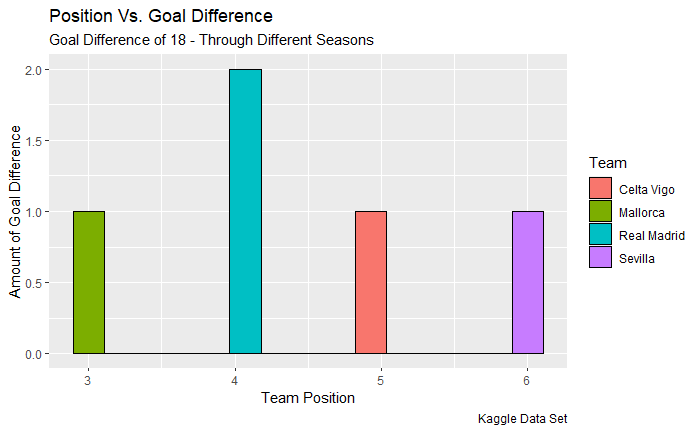

```r
ggplot(data = GD18) + geom_histogram(mapping = aes(x = Position, fill = Team), color = "black", bins = 15) + labs(title = "Position Vs. Goal Difference", subtitle = "Goal Difference of 18 - Through Different Seasons", x = "Team Position", y = "Amount of Goal Difference", caption = "Kaggle Data Set")
```

## Checking the Skewness of the Histogram

```r
# Calculate Skewness
skewness(GD18$Position)
```

```
[1] 0.2715454
```

```r
# Calculate Kurtosis
kurtosis(GD18$Position)
```

```
[1] 1.955621
```

```r
# Goodness-of-fit test that determines whether or not sample data have skewness and kurtosis that matches a normal distribution.

# Null Hypothesis: The data set has a skewness and kurtosis that matches a normal distribution.

# Alternative Hypothesis: The data set has a skewness and kurtosis that does not match a normal distribution.

jarque.test(GD18$Position)
```

```
    Jarque-Bera Normality Test

data:  GD18$Position
JB = 0.28868, p-value = 0.8656
alternative hypothesis: greater
```

```r
cat("The p-value of the test turns out to be 0.8656. Since this value is not less than α = .05, we fail to rejec the null hypothesis. We do not have sufficient evidence to say that this dataset has a skewness and kurtosis that is different from the normal distribution. ")
```

```
The p-value of the test turns out to be 0.8656. Since this value is not less than a = .05, we fail to rejec the null hypothesis. We do not have sufficient evidence to say that this dataset has a skewness and kurtosis that is different from the normal distribution.
```

Follow up: The Histogram Distribution helps me identify how many teams had a goal difference of 18 through different seasons. For example, in two different seasons Real Madrid had a goal difference of 18, while positioning themselves at the fourth position each seasons.

# Second Quesiton

## How many teams have scored less than or equal to 23 in one season, predict the score and display its visuals.

```r
# How many teams have scored less than or equal to 23 in different seasons.

# Create a data frame with a single score entry.

scoreEqualto23 <- data_frame(Scored = c(23))

scoreEqualto23
```

| Scored |
| --- |
| 23 |

## Linear Regression

```r
ModelScore <- lm(data = LaLiga, Position ~ Scored)

ModelScore
```

```
Call:
lm(formula = Position ~ Scored, data = LaLiga)

Coefficients:
(Intercept)       Scored
    23.3501      -0.2543
```

## Predict the scored with the data set and test data set

```
#> Predict the scored with the data set and test data set
```

```r
PredictedScoredSecondQuestion <- predict(ModelScore, scoreEqualto23)
cat("At score equal to 23 or less, the position is: ", PredictedScoredSecondQuestion)
```

```
At score equal to 23 or less, the position is:  17.50189
```

## Verification

```r
# Let's see the average scored of teams with a less than or equal to 23 score

# Output table with position of the teams that scored <= 23

scored23 <- subset(LaLiga, Scored <= 23)

scored23
```

|  | Season | Position | Crest.names | Team | City | Points | Matches | Won | Draw | Lost | Scored | Conceded | GoalDifference |
| --- | --- | --- | --- | --- | --- | --- | --- | --- | --- | --- | --- | --- | --- |
| 57 | 1989-90 | 17 | CD Málaga | Málaga | Málaga | 28 | 38 | 9 | 10 | 19 | 23 | 50 | -27 |
| 160 | 1994-95 | 20 | CD Logroñés | Logroñés | Logroño | 13 | 38 | 2 | 9 | 27 | 15 | 79 | -64 |
| 564 | 2014-15 | 20 | Córdoba CF | Córdoba | Córdoba | 20 | 38 | 3 | 11 | 24 | 22 | 68 | -46 |

## Calculating the Statistical Data

```
#> Calculate the average and SD of position when score is <= 23
```

```r
ScoredAverage <- mean(scored23$Scored)

cat("Average:", ScoredAverage)
```

```
Average: 20
```

```r
ScoredSD <- sd(scored23$Scored)

cat("\nSD:", ScoredSD)
```

```
SD: 4.358899
```

```r
ScoredRange <- range(scored23$Scored)

cat("\nRange:", ScoredRange)
```

```
Range: 15 23
```

```r
ScoredMedian <- median(scored23$Scored)

cat("\nMedian:",ScoredMedian)
```

```
Median: 22
```

## Calculating the Data’s Skewedness

## Shapiro-Wilk with the scored23 data set

```r
# If the function is greater than 5% or 0.05 than it is normally distributed.

shapiro.test(scored23$Scored)
```

```
    Shapiro-Wilk normality test

data:  scored23$Scored
W = 0.84211, p-value = 0.2196
```

ANSWER: The plot is normally distributed because the p-value that is given from the function is greater than 0.05 or 5% making the data set a normally distributed plot.

## Second Distribution Histogram

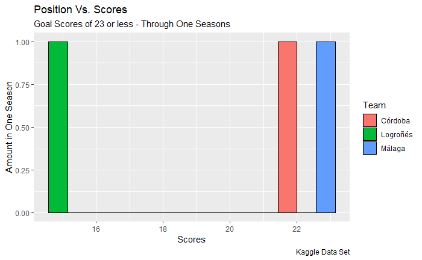

```r
ggplot(data = scored23) + geom_histogram(mapping = aes(x = Scored, fill = Team), color = "black", bins = 15) + labs(title = "Position Vs. Scores", subtitle = "Goal Scores of 23 or less - Through One Seasons", x = "Scores", y = "Amount in One Season", caption = "Kaggle Data Set")
```

## Checking the Skewness of the Histogram

```r
# Calculate Skewness
skewness(scored23$Scored)
```

```
[1] -0.6654689
```

```r
# Calculate Kurtosis
kurtosis(scored23$Scored)
```

```
[1] 1.5
```

```r
# Goodness-of-fit test that determines whether or not sample data have skewness and kurtosis that matches a normal distribution.

# Null Hypothesis: The data set has a skewness and kurtosis that matches a normal distribution.

# Alternative Hypothesis: The data set has a skewness and kurtosis that does not match a normal distribution.

jarque.test(scored23$Scored)
```

```
    Jarque-Bera Normality Test

data:  scored23$Scored
JB = 0.50267, p-value = 0.7778
alternative hypothesis: greater
```

```r
cat("The p-value of the test turns out to be 0.7778. Since this value is not less than α = .05, we fail to rejec the null hypothesis. We do not have sufficient evidence to say that this dataset has a skewness and kurtosis that is different from the normal distribution. ")
```

```
The p-value of the test turns out to be 0.7778. Since this value is not less than a = .05, we fail to rejec the null hypothesis. We do not have sufficient evidence to say that this dataset has a skewness and kurtosis that is different from the normal distribution.
```

# Third Question

## How many teams has had at least 30 or greater wins in a given season, predict the win and display its visuals.

```r
# How many teams has had at least 30 or greater wins in a given season

# Create a data frame with a single win entry.

Liga30Wins <- data_frame(Won = c(30))

Liga30Wins
```

| Won |
| --- |
| 30 |

## Linear Regression

```r
ModelWins <- lm(data = LaLiga, Position ~ Won)

ModelWins
```

```
Call:
lm(formula = Position ~ Won, data = LaLiga)

Coefficients:
(Intercept)          Won
    24.3714      -0.9751
```

## Predict the wins with the data set and test data set

```
#> Predict the scored with the data set and test data set
```

```r
PredictedWonsThirdQuestion <- predict(ModelWins, Liga30Wins)
cat("At wins equal to 30 or greater, the position is: ", PredictedWonsThirdQuestion)
```

```
At wins equal to 30 or greater, the position is:  -4.882128
```

## Verification

```r
# Let's see the average wins of at least 30 or greater

# Output table with wins at 30 or greater

Wins30 <- subset(LaLiga, Won >= 30)

Wins30
```

|  | Season | Position | Crest.names | Team | City | Points | Matches | Won | Draw | Lost | Scored | Conceded | GoalDifference |
| --- | --- | --- | --- | --- | --- | --- | --- | --- | --- | --- | --- | --- | --- |
| 445 | 2009-10 | 1 | FC Barcelona | Barcelona | Barcelona | 99 | 38 | 31 | 6 | 1 | 98 | 24 | 74 |
| 446 | 2009-10 | 2 | Real Madrid | Real Madrid | Madrid | 96 | 38 | 31 | 3 | 4 | 102 | 35 | 67 |
| 465 | 2010-11 | 1 | FC Barcelona | Barcelona | Barcelona | 96 | 38 | 30 | 6 | 2 | 95 | 21 | 74 |
| 485 | 2011-12 | 1 | Real Madrid | Real Madrid | Madrid | 100 | 38 | 32 | 4 | 2 | 121 | 32 | 89 |
| 505 | 2012-13 | 1 | FC Barcelona | Barcelona | Barcelona | 100 | 38 | 32 | 4 | 2 | 115 | 40 | 75 |
| 545 | 2014-15 | 1 | FC Barcelona | Barcelona | Barcelona | 94 | 38 | 30 | 4 | 4 | 110 | 21 | 89 |
| 546 | 2014-15 | 2 | Real Madrid | Real Madrid | Madrid | 92 | 38 | 30 | 2 | 6 | 118 | 38 | 80 |

## Calculating the Statistical Data

```
#> Calculate the average and SD of wins when wins is >= 30
```

```r
WonAverage <- mean(Wins30$Won)

cat("Average:", WonAverage)
```

```
Average: 30.85714
```

```r
WinsSD <- sd(Wins30$Won)

cat("\nSD:", WinsSD)
```

```
SD: 0.8997354
```

```r
WinsRange <- range(Wins30$Won)

cat("\nRange:", WinsRange)
```

```
Range: 30 32
```

```r
WinsMedian <- median(Wins30$Won)

cat("\nMedian:", WinsMedian)
```

```
Median: 31
```

## Calculating the Data’s Skewedness

## Shapiro-Wilk with the Wins30 data set

```r
# If the function is greater than 5% or 0.05 than it is normally distributed.

shapiro.test(Wins30$Won)
```

```
    Shapiro-Wilk normality test

data:  Wins30$Won
W = 0.81809, p-value = 0.06155
```

ANSWER: The plot is normally distributed because the p-value that is given from the function is greater than 0.05 or 5% making the data set a normally distributed.

## Third Distribution Histogram

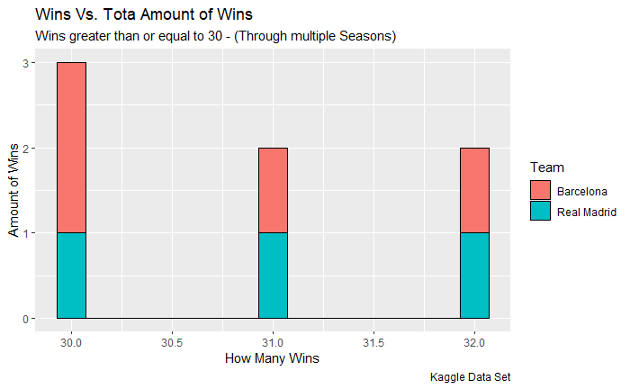

```r
ggplot(data = Wins30) + geom_histogram(mapping = aes(x = Won, fill = Team), color = "black", bins = 15) + labs(title = "Wins Vs. Tota Amount of Wins", subtitle = "Wins greater than or equal to 30 - (Through multiple Seasons)", x = "How Many Wins", y = "Amount of Wins", caption = "Kaggle Data Set")
```

## Checking the Skewness of the Histogram

```r
# Calculate Skewness
skewness(Wins30$Won)
```

```
[1] 0.2723801
```

```r
# Calculate Kurtosis
kurtosis(Wins30$Won)
```

```
[1] 1.49308
```

```r
# Goodness-of-fit test that determines whether or not sample data have skewness and kurtosis that matches a normal distribution.

# Null Hypothesis: The data set has a skewness and kurtosis that matches a normal distribution.

# Alternative Hypothesis: The data set has a skewness and kurtosis that does not match a normal distribution.

jarque.test(Wins30$Won)
```

```
    Jarque-Bera Normality Test

data:  Wins30$Won
JB = 0.74888, p-value = 0.6877
alternative hypothesis: greater
```

```r
cat("The p-value of the test turns out to be 0.6877. Since this value is not less than α = .05, we fail to rejec the null hypothesis. We do not have sufficient evidence to say that this dataset has a skewness and kurtosis that is different from the normal distribution. ")
```

```
The p-value of the test turns out to be 0.6877. Since this value is not less than a = .05, we fail to rejec the null hypothesis. We do not have sufficient evidence to say that this dataset has a skewness and kurtosis that is different from the normal distribution.
```

Follow up: The Histogram Distribution helps me identify how many teams had won at least 30 or more through a season. For example, in multiple seasons, Barcelona has had at least two season with 30 wins. On the other hand, Real Madrid has but only one seasons with 30 wins.